# Westerns over time

Grace Zhan, Sabrina Sayasith

April 17, 2016

```r
library(mdsr)
library(DBI)
library(RMySQL)
library(tm)
library(wordcloud)
library(plotly)
db <- dbConnect_scidb(dbname = "imdb")
```

```r
# number of Western movies produced each year
western <- db %>%
  dbGetQuery("SELECT t.production_year, sum(1) as numWesterns
             FROM title t
             JOIN movie_info mi on t.id = mi.movie_id
             WHERE mi.info_type_id = 3
             AND mi.info like 'Western'
             AND t.kind_id = 1
             GROUP BY t.production_year;")

# number of all movies produced each year
total <- db %>%
  dbGetQuery("SELECT t.production_year, sum(1) as N
             FROM title t
             WHERE t.kind_id = 1
             GROUP BY t.production_year;")

#average rating of Western movies per year:
westReadings <- db %>%
  dbGetQuery("
SELECT t.production_year, sum(1) as totalWesratings, avg(mii.info) as avgRating
FROM title t
JOIN movie_info_idx mii ON mii.movie_id = t.id
JOIN movie_info mi on t.id = mi.movie_id
WHERE t.kind_id = 1
AND mii.info_type_id = 101
AND mi.info_type_id = 3
AND mi.info like 'Western'
GROUP BY t.production_year;")
```

```r
# compare the percentage of movies across similar genres
#number of Action movies each production year
action <- db %>%
  dbGetQuery("SELECT t.production_year, sum(1) as numActions
             FROM title t
             JOIN movie_info mi on t.id = mi.movie_id
             WHERE mi.info_type_id = 3
             AND mi.info like 'Action'
             AND t.kind_id = 1
             GROUP BY t.production_year;")

#number of Adventure movies each production year
Adventure <- db %>%
  dbGetQuery("SELECT t.production_year, sum(1) as numAdventure
             FROM title t
             JOIN movie_info mi on t.id = mi.movie_id
             WHERE mi.info_type_id = 3
             AND mi.info like 'Adventure'
             AND t.kind_id = 1
             GROUP BY t.production_year;")

combine <- left_join(western, action, by = c("production_year"))

combine1 <- left_join(combine, Adventure, by = c("production_year"))

combine2 <- left_join(combine1, total, by = c("production_year"))

combine2 <- combine2 %>%
  mutate(percWestern = numWesterns*100/N) %>%
  mutate(percAction = numActions*100/N) %>%
  mutate(perAdventure = numAdventure*100/N)

combine3 <- "~/Desktop/combine3.csv"
combine3 <- read.csv(combine3)

# to see if the percentage of western movies and average ratings of western movies have relatively same trend over the years

d <- ggplot(data = combine2, aes(x = production_year, y = percWestern)) + geom_line() + labs(x="Production Year",y="percentage of Western movies") + scale_x_continuous(limits=c(1894, 2016)) + scale_y_continuous(breaks = c(0,2.5,5, 7.5,10),labels = c("0%", "2.5%", "5%","7.5%", "10%")) + theme_classic()+ ggtitle("Percentage of Films that are Westerns")

p <- ggplot(data = westReadings, aes(x= production_year, y = avgRating)) + geom_line() + scale_y_continuous(limits=c(3, 9), breaks = c(3, 5, 7, 9)) + labs(x="Production Year",y="Average rating of Western movies") + theme_classic() + ggtitle("Average Rating of Western Films per Year")
```

```r
ggplotly(d)
```

[interactive chart not shown]

According to Wikipedia, the Western was the most popular Hollywood genre from the early 20th century to the 1960s. Western films first became well-attended in the 1930s, and were very popular throughout the 1950s and 1960s.

From the graph, we can see that the percentage of western movies really fluctuated over the years, especially between 1900-1980. The percentage of Western movies reached its peak in 1925 where 8.94% of all movies are western.

```r
ggplotly(p)
```

[interactive chart not shown]

We were wondering if the fluctuations of the percentage of Western movies are related to the ratings. For example, when people think the Western movies are not as good anymore, they will choose to watch less Western movies. Thus, less Western movies will be produced in the following year. However, the older the movie, the less number of ratings it received on IMDB since ratings are rated by people nowaways, and not much people watch old films. It is also hard to tell if people in the past would rate Western movies the same as people nowadays becuase people’s mindset have definitely changed over the years.

```r
f <- ggplot(data= combine3, aes(x= production_year, y = percentage)) + geom_line() + facet_wrap(~Genre) + scale_x_continuous(limits=c(1894, 2016)) + scale_y_continuous(limits = c(0, 10), breaks = c(0,2.5,5, 7.5,10),labels = c("0%", "2.5%", "5%","7.5%", "10%")) + labs(x="Production Year",y="percentage")

ggplotly(f)
```

[interactive chart not shown]

We also went to IMDB’s website to find similar genres, which are Action and Adventure. We were wondering if a rise in Action or Adventure movies might cause a fall in the Western movies. From the graphs we can see that the percantage of Action movies increased a lot from 1950 (2.8%) to 1990 (9.84%). In the same period, Western movies faced one of its biggest downfalls, from 5.67% in 1950 to 0.29% in 1990. However, we cannot simply conclude that the rise of Action movies affected the Western movie market. One reason is that the percentage of Adventure movies also fell a lot during the same period, and there are also many other reasons that need to be put into consideration.

```r
#Plot - check for most common words
#id 9 taglines
#id 10 keywords
#id 98 is plot
#id 3 is genre


#table with plot
sql <- "
SELECT t.title, t.id, t.production_year, mi.info AS Plot
FROM title t
JOIN movie_info mi ON mi.movie_id = t.id
WHERE t.kind_id = 1
AND mi.info_type_id = 98
ORDER BY t.production_year;
"

#table with Westerns
sql1 <- "
SELECT t.title, t.id, t.production_year
FROM title t
JOIN movie_info mi on t.id = mi.movie_id
WHERE mi.info_type_id = 3
AND mi.info like 'Western'
AND t.kind_id = 1
ORDER BY t.production_year;
"

westerns <- db %>%
  dbGetQuery(sql1)

filmPlots <- db %>%
  dbGetQuery(sql)

joinedWesternPlots <- inner_join(westerns, filmPlots, by = "id") %>%
  select(-title.x, -production_year.x)

joinedWestern1940 <- joinedWesternPlots %>%
  filter(production_year.y >= 1940 & production_year.y <= 1960)

#source: https://deltadna.com/blog/text-mining-in-r-for-term-frequency/
#collapse all text into one big blob
review_text1940 <- paste(joinedWestern1940$Plot, collapse=" ")

#create corpus
review_source1940 <- VectorSource(review_text1940)
corpus1940 <- Corpus(review_source1940)

#transform everything to lowercase, remove punctuation, clean text, remove common words
corpus1940 <- tm_map(corpus1940, content_transformer(tolower))
corpus1940 <- tm_map(corpus1940, removePunctuation)
corpus1940 <- tm_map(corpus1940, stripWhitespace)
corpus1940.nostopwords <- tm_map(corpus1940, removeWords, stopwords("english"))

#word matrix
dtm1940 <- DocumentTermMatrix(corpus1940.nostopwords)
dtm21940 <- as.matrix(dtm1940)


#table with frequencies of each word
frequency1940 <- colSums(dtm21940)
frequency1940 <- sort(frequency1940, decreasing=TRUE)

#colors
pal2 <- brewer.pal(9,"Spectral")
```

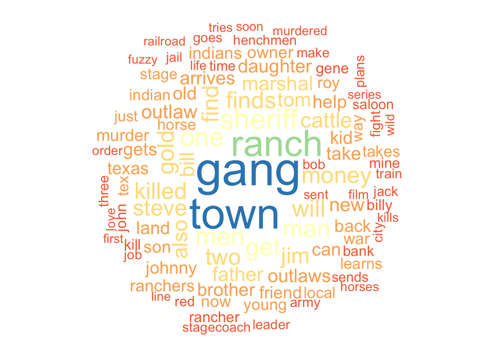

```r
joinedWestern2000 <- joinedWesternPlots %>%
  filter(production_year.y >= 2000)


#source: https://deltadna.com/blog/text-mining-in-r-for-term-frequency/
#collapse all text into one big blob
review_text2000 <- paste(joinedWestern2000$Plot, collapse=" ")

#create corpus
review_source2000 <- VectorSource(review_text2000)
corpus2000 <- Corpus(review_source2000)

#transform everything to lowercase, remove punctuation, clean text, remove common words
corpus2000 <- tm_map(corpus2000, content_transformer(tolower))
corpus2000 <- tm_map(corpus2000, removePunctuation)
corpus2000 <- tm_map(corpus2000, stripWhitespace)
corpus2000.nostopwords <- tm_map(corpus2000, removeWords, stopwords("english"))


#word matrix
dtm2000 <- DocumentTermMatrix(corpus2000.nostopwords)
dtm22000 <- as.matrix(dtm2000)

#table with frequencies of each word
frequency2000 <- colSums(dtm22000)
frequency2000 <- sort(frequency2000, decreasing=TRUE)

#colors
pal2 <- brewer.pal(9,"Spectral")

#word cloud of 1940 - 1960
words1940 <- names(frequency1940)
wordcloud(words1940[1:100], frequency1940[1:100], random.order = FALSE, colors = pal2)
```

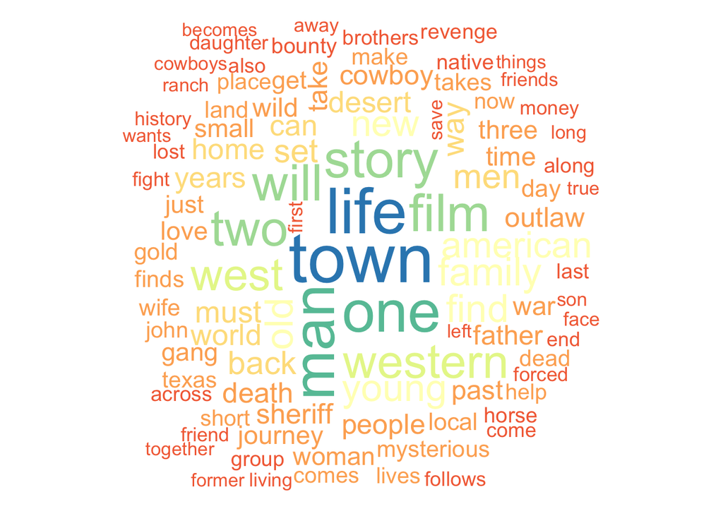

```r
#word cloud from 2000 and onward
words2000 <- names(frequency2000)
wordcloud(words2000[1:100], frequency2000[1:100], random.order = FALSE, colors = pal2)
```

We wanted to know if the words used to describe the plots of Western movies had changed over time. We took the film plots of all of the Western movies with production years from 1940 - 1960 and all of the plots from Westerns with production years from 2000 onward. For each time frame, we took the 100 most frequent words used.

For 1940-1960, the most frequent words used are gang, ranch, town, sheriff, one, man, men, get, cattle, money, marshal, jim, steve, and two. For 2000 and onward, the most common words are town, life, one, film, western, american, story, family, old, two, young, new, find, war, home, and desert.

The setting of a town remains central to the idea of a Western throughout time. Texas in particular is a popular area for Westerners To be set in. The plot having to do with murder, killing, money, and family also doesn’t change. Gangs seem to be much more popular in the older Western movies.